# DROPOUT OR GRADUATE CLASSIFIER

A MODEL TO PREDICT WHETHER AN INDIVIDUAL DROPS OUT OF SCHOOL OR GRADUATE

### Group Members

| NAME | SURNAME | REG NO | PROGRAM |
| --- | --- | --- | --- |
| MUNASHE | TARINGA | R231531S | HCS |
| MPHO | RUZWIDZO | R231606H | HAI |
| ANESU | MUTAMBA | R236546Z | HAI |
| KELVIN | MABVURUDZA | R231631N | HAI |
| TAMIRANASHE | MUTASA | R216897M | HAI |

### 📘 Background

Education is a key driver of personal and societal development. However, many students around the world fail to complete their education due to various factors such as financial difficulties, lack of support, poor academic performance, and more. Understanding the reasons behind student dropout is crucial for educational institutions aiming to improve student retention and success rates.

This project, **"Dropout or Graduate Classifier"**, leverages machine learning techniques to analyze student-related data and predict whether a student is likely to **graduate** or **drop out**. By identifying at-risk students early, institutions can provide targeted interventions and support to improve outcomes.

The classifier is built using several supervised learning algorithms and is trained on historical data including academic, demographic, and socio-economic features. The goal is to create a reliable predictive model that can aid in decision-making for educators and policymakers.

# IMPORTING LIBRARIES

```python
# Importing necessary libraries
import numpy as np
import pandas as pd
import matplotlib.pyplot as plt
import seaborn as sns
from sklearn.model_selection import train_test_split
from sklearn.preprocessing import LabelEncoder, StandardScaler
from sklearn.metrics import accuracy_score, precision_score, recall_score, f1_score, roc_auc_score, confusion_matrix, classification_report

#to ignore warnings
import warnings
warnings.filterwarnings('ignore')


# Importing machine learning algorithms
from sklearn.linear_model import LogisticRegression
from sklearn.tree import DecisionTreeClassifier
from sklearn.ensemble import RandomForestClassifier
from sklearn.svm import SVC
from sklearn.neighbors import KNeighborsClassifier
from sklearn.ensemble import GradientBoostingClassifier

# For model evaluation
from sklearn.model_selection import cross_val_score
```

# READING OUR DATASET

```python
data = pd.read_csv("C:/Users/HP ELITEBOOK 840 G5/Desktop/PROJECT12/data.csv", sep=";")
```

# ANALYTICS AND PREPROCESSING

```python
#reading the first 5 records
data.head(5)
```

|  | Marital status | Application mode | Application order | Course | Daytime/evening attendance\t | Previous qualification | Previous qualification (grade) | Nacionality | Mother's qualification | Father's qualification | ... | Curricular units 2nd sem (credited) | Curricular units 2nd sem (enrolled) | Curricular units 2nd sem (evaluations) | Curricular units 2nd sem (approved) | Curricular units 2nd sem (grade) | Curricular units 2nd sem (without evaluations) | Unemployment rate | Inflation rate | GDP | Target |
| --- | --- | --- | --- | --- | --- | --- | --- | --- | --- | --- | --- | --- | --- | --- | --- | --- | --- | --- | --- | --- | --- |
| 0 | 1 | 17 | 5 | 171 | 1 | 1 | 122.0 | 1 | 19 | 12 | ... | 0 | 0 | 0 | 0 | 0.000000 | 0 | 10.8 | 1.4 | 1.74 | Dropout |
| 1 | 1 | 15 | 1 | 9254 | 1 | 1 | 160.0 | 1 | 1 | 3 | ... | 0 | 6 | 6 | 6 | 13.666667 | 0 | 13.9 | -0.3 | 0.79 | Graduate |
| 2 | 1 | 1 | 5 | 9070 | 1 | 1 | 122.0 | 1 | 37 | 37 | ... | 0 | 6 | 0 | 0 | 0.000000 | 0 | 10.8 | 1.4 | 1.74 | Dropout |
| 3 | 1 | 17 | 2 | 9773 | 1 | 1 | 122.0 | 1 | 38 | 37 | ... | 0 | 6 | 10 | 5 | 12.400000 | 0 | 9.4 | -0.8 | -3.12 | Graduate |
| 4 | 2 | 39 | 1 | 8014 | 0 | 1 | 100.0 | 1 | 37 | 38 | ... | 0 | 6 | 6 | 6 | 13.000000 | 0 | 13.9 | -0.3 | 0.79 | Graduate |

5 rows × 37 columns

```python
#READING THE LAST 5 RECORDS
data.tail(5)
```

|  | Marital status | Application mode | Application order | Course | Daytime/evening attendance\t | Previous qualification | Previous qualification (grade) | Nacionality | Mother's qualification | Father's qualification | ... | Curricular units 2nd sem (credited) | Curricular units 2nd sem (enrolled) | Curricular units 2nd sem (evaluations) | Curricular units 2nd sem (approved) | Curricular units 2nd sem (grade) | Curricular units 2nd sem (without evaluations) | Unemployment rate | Inflation rate | GDP | Target |
| --- | --- | --- | --- | --- | --- | --- | --- | --- | --- | --- | --- | --- | --- | --- | --- | --- | --- | --- | --- | --- | --- |
| 4419 | 1 | 1 | 6 | 9773 | 1 | 1 | 125.0 | 1 | 1 | 1 | ... | 0 | 6 | 8 | 5 | 12.666667 | 0 | 15.5 | 2.8 | -4.06 | Graduate |
| 4420 | 1 | 1 | 2 | 9773 | 1 | 1 | 120.0 | 105 | 1 | 1 | ... | 0 | 6 | 6 | 2 | 11.000000 | 0 | 11.1 | 0.6 | 2.02 | Dropout |
| 4421 | 1 | 1 | 1 | 9500 | 1 | 1 | 154.0 | 1 | 37 | 37 | ... | 0 | 8 | 9 | 1 | 13.500000 | 0 | 13.9 | -0.3 | 0.79 | Dropout |
| 4422 | 1 | 1 | 1 | 9147 | 1 | 1 | 180.0 | 1 | 37 | 37 | ... | 0 | 5 | 6 | 5 | 12.000000 | 0 | 9.4 | -0.8 | -3.12 | Graduate |
| 4423 | 1 | 10 | 1 | 9773 | 1 | 1 | 152.0 | 22 | 38 | 37 | ... | 0 | 6 | 6 | 6 | 13.000000 | 0 | 12.7 | 3.7 | -1.70 | Graduate |

5 rows × 37 columns

```python
print(data.info())
```

```
<class 'pandas.core.frame.DataFrame'>
RangeIndex: 4424 entries, 0 to 4423
Data columns (total 37 columns):
 #   Column                                          Non-Null Count  Dtype
---  ------                                          --------------  -----
 0   Marital status                                  4424 non-null   int64
 1   Application mode                                4424 non-null   int64
 2   Application order                               4424 non-null   int64
 3   Course                                          4424 non-null   int64
 4   Daytime/evening attendance	                     4424 non-null   int64
 5   Previous qualification                          4424 non-null   int64
 6   Previous qualification (grade)                  4424 non-null   float64
 7   Nacionality                                     4424 non-null   int64
 8   Mother's qualification                          4424 non-null   int64
 9   Father's qualification                          4424 non-null   int64
```

[output cut: 30 more lines]

```python
data.describe()
```

|  | Marital status | Application mode | Application order | Course | Daytime/evening attendance\t | Previous qualification | Previous qualification (grade) | Nacionality | Mother's qualification | Father's qualification | ... | Curricular units 1st sem (without evaluations) | Curricular units 2nd sem (credited) | Curricular units 2nd sem (enrolled) | Curricular units 2nd sem (evaluations) | Curricular units 2nd sem (approved) | Curricular units 2nd sem (grade) | Curricular units 2nd sem (without evaluations) | Unemployment rate | Inflation rate | GDP |
| --- | --- | --- | --- | --- | --- | --- | --- | --- | --- | --- | --- | --- | --- | --- | --- | --- | --- | --- | --- | --- | --- |
| count | 4424.000000 | 4424.000000 | 4424.000000 | 4424.000000 | 4424.000000 | 4424.000000 | 4424.000000 | 4424.000000 | 4424.000000 | 4424.000000 | ... | 4424.000000 | 4424.000000 | 4424.000000 | 4424.000000 | 4424.000000 | 4424.000000 | 4424.000000 | 4424.000000 | 4424.000000 | 4424.000000 |
| mean | 1.178571 | 18.669078 | 1.727848 | 8856.642631 | 0.890823 | 4.577758 | 132.613314 | 1.873192 | 19.561935 | 22.275316 | ... | 0.137658 | 0.541817 | 6.232143 | 8.063291 | 4.435805 | 10.230206 | 0.150316 | 11.566139 | 1.228029 | 0.001969 |
| std | 0.605747 | 17.484682 | 1.313793 | 2063.566416 | 0.311897 | 10.216592 | 13.188332 | 6.914514 | 15.603186 | 15.343108 | ... | 0.690880 | 1.918546 | 2.195951 | 3.947951 | 3.014764 | 5.210808 | 0.753774 | 2.663850 | 1.382711 | 2.269935 |
| min | 1.000000 | 1.000000 | 0.000000 | 33.000000 | 0.000000 | 1.000000 | 95.000000 | 1.000000 | 1.000000 | 1.000000 | ... | 0.000000 | 0.000000 | 0.000000 | 0.000000 | 0.000000 | 0.000000 | 0.000000 | 7.600000 | -0.800000 | -4.060000 |
| 25% | 1.000000 | 1.000000 | 1.000000 | 9085.000000 | 1.000000 | 1.000000 | 125.000000 | 1.000000 | 2.000000 | 3.000000 | ... | 0.000000 | 0.000000 | 5.000000 | 6.000000 | 2.000000 | 10.750000 | 0.000000 | 9.400000 | 0.300000 | -1.700000 |
| 50% | 1.000000 | 17.000000 | 1.000000 | 9238.000000 | 1.000000 | 1.000000 | 133.100000 | 1.000000 | 19.000000 | 19.000000 | ... | 0.000000 | 0.000000 | 6.000000 | 8.000000 | 5.000000 | 12.200000 | 0.000000 | 11.100000 | 1.400000 | 0.320000 |
| 75% | 1.000000 | 39.000000 | 2.000000 | 9556.000000 | 1.000000 | 1.000000 | 140.000000 | 1.000000 | 37.000000 | 37.000000 | ... | 0.000000 | 0.000000 | 7.000000 | 10.000000 | 6.000000 | 13.333333 | 0.000000 | 13.900000 | 2.600000 | 1.790000 |
| max | 6.000000 | 57.000000 | 9.000000 | 9991.000000 | 1.000000 | 43.000000 | 190.000000 | 109.000000 | 44.000000 | 44.000000 | ... | 12.000000 | 19.000000 | 23.000000 | 33.000000 | 20.000000 | 18.571429 | 12.000000 | 16.200000 | 3.700000 | 3.510000 |

8 rows × 36 columns

```python
#CHECKING FOR NULL VALUES IN OUR DATASET
data.isnull().sum()
```

```
Marital status                                    0
Application mode                                  0
Application order                                 0
Course                                            0
Daytime/evening attendance\t                      0
Previous qualification                            0
Previous qualification (grade)                    0
Nacionality                                       0
Mother's qualification                            0
Father's qualification                            0
Mother's occupation                               0
Father's occupation                               0
Admission grade                                   0
Displaced                                         0
Educational special needs                         0
Debtor                                            0
Tuition fees up to date                           0
Gender                                            0
Scholarship holder                                0
Age at enrollment                                 0
International                                     0
Curricular units 1st sem (credited)               0
Curricular units 1st sem (enrolled)               0
Curricular units 1st sem (evaluations)            0
Curricular units 1st sem (approved)               0
Curricular units 1st sem (grade)                  0
Curricular units 1st sem (without evaluations)    0
Curricular units 2nd sem (credited)               0
Curricular units 2nd sem (enrolled)               0
Curricular units 2nd sem (evaluations)            0
Curricular units 2nd sem (approved)               0
Curricular units 2nd sem (grade)                  0
Curricular units 2nd sem (without evaluations)    0
Unemployment rate                                 0
Inflation rate                                    0
GDP                                               0
Target                                            0
dtype: int64
```

```python
#CHECKING FOR DUPLICATE RECORDS WHICH MIGHT ADD NOISE TO OUR MODEL
print(data.duplicated().sum())
```

```
0
```

# DATA PREPROCESSING

```python
from sklearn.preprocessing import LabelEncoder

#Selecting the very best features for the model
selected_features = [
    'Gender',
    'Age at enrollment',
    'Previous qualification',
    'Previous qualification (grade)',
    'Admission grade',
    'Curricular units 1st sem (approved)',
    'Curricular units 2nd sem (approved)',
    'Curricular units 1st sem (grade)',
    'Curricular units 2nd sem (grade)',
    'Scholarship holder',
    'Educational special needs',
    'Tuition fees up to date',
    'Unemployment rate',
    'Inflation rate',
    'Target'  # This is the graduation/dropout variable
]

# Filtering the DataFrame to keep only selected features
data = data[selected_features]

# Checking the initial DataFrame
print("Initial DataFrame:")
print(data.head())

# Converting the categorical variables to numerical values
# For binary or ordinal features (if applicable)
label_encoder = LabelEncoder()

# Applying label encoding to binary categorical features
data['Gender'] = label_encoder.fit_transform(data['Gender'])
data['Previous qualification'] = label_encoder.fit_transform(data['Previous qualification'])
data['Scholarship holder'] = label_encoder.fit_transform(data['Scholarship holder'])
data['Educational special needs'] = label_encoder.fit_transform(data['Educational special needs'])
data['Target'] = label_encoder.fit_transform(data['Target'])  # Assuming 'Target' is also a binary variable

# For other categorical features, one-hot encoding is used
data = pd.get_dummies(data, columns=['Previous qualification'], drop_first=True)

# Checking for the filtered DataFrame with encoded values
print("Filtered DataFrame with Encoded Values:")
data.head()
```

```
Initial DataFrame:
   Gender  Age at enrollment  Previous qualification  \
0       1                 20                       1
1       1                 19                       1
2       1                 19                       1
3       0                 20                       1
4       0                 45                       1

   Previous qualification (grade)  Admission grade  \
0                           122.0            127.3
1                           160.0            142.5
2                           122.0            124.8
3                           122.0            119.6
4                           100.0            141.5

   Curricular units 1st sem (approved)  Curricular units 2nd sem (approved)  \
0                                    0                                    0
1                                    6                                    6
2                                    0                                    0
3                                    6                                    5
4                                    5                                    6

   Curricular units 1st sem (grade)  Curricular units 2nd sem (grade)  \
0                          0.000000                          0.000000
1                         14.000000                         13.666667
2                          0.000000                          0.000000
3                         13.428571                         12.400000
4                         12.333333                         13.000000

   Scholarship holder  Educational special needs  Tuition fees up to date  \
0                   0                          0                        1
1                   0                          0                        0
2                   0                          0                        0
3                   0                          0                        1
4                   0                          0                        1

   Unemployment rate  Inflation rate    Target
0               10.8             1.4   Dropout
1               13.9            -0.3  Graduate
2               10.8             1.4   Dropout
3                9.4            -0.8  Graduate
4               13.9            -0.3  Graduate
Filtered DataFrame with Encoded Values:
```

|  | Gender | Age at enrollment | Previous qualification (grade) | Admission grade | Curricular units 1st sem (approved) | Curricular units 2nd sem (approved) | Curricular units 1st sem (grade) | Curricular units 2nd sem (grade) | Scholarship holder | Educational special needs | ... | Previous qualification_7 | Previous qualification_8 | Previous qualification_9 | Previous qualification_10 | Previous qualification_11 | Previous qualification_12 | Previous qualification_13 | Previous qualification_14 | Previous qualification_15 | Previous qualification_16 |
| --- | --- | --- | --- | --- | --- | --- | --- | --- | --- | --- | --- | --- | --- | --- | --- | --- | --- | --- | --- | --- | --- |
| 0 | 1 | 20 | 122.0 | 127.3 | 0 | 0 | 0.000000 | 0.000000 | 0 | 0 | ... | False | False | False | False | False | False | False | False | False | False |
| 1 | 1 | 19 | 160.0 | 142.5 | 6 | 6 | 14.000000 | 13.666667 | 0 | 0 | ... | False | False | False | False | False | False | False | False | False | False |
| 2 | 1 | 19 | 122.0 | 124.8 | 0 | 0 | 0.000000 | 0.000000 | 0 | 0 | ... | False | False | False | False | False | False | False | False | False | False |
| 3 | 0 | 20 | 122.0 | 119.6 | 6 | 5 | 13.428571 | 12.400000 | 0 | 0 | ... | False | False | False | False | False | False | False | False | False | False |
| 4 | 0 | 45 | 100.0 | 141.5 | 5 | 6 | 12.333333 | 13.000000 | 0 | 0 | ... | False | False | False | False | False | False | False | False | False | False |

5 rows × 30 columns

# ADDING VISUALS TO INTERPRET OUR DATASET

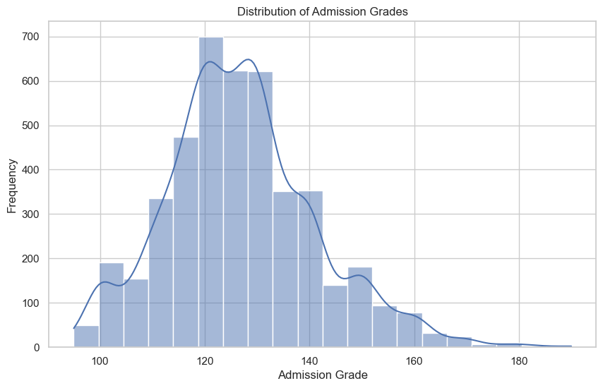

```python
# 1. Distribution of Admission Grades
plt.figure(figsize=(10, 6))
sns.histplot(data['Admission grade'], bins=20, kde=True)
plt.title('Distribution of Admission Grades')
plt.xlabel('Admission Grade')
plt.ylabel('Frequency')
plt.show()
```

[figure not shown]

```python
# 2. Gender Distribution
plt.figure(figsize=(8, 5))
sns.countplot(x='Gender', data=data)
plt.title('Gender Distribution of Students')
plt.xlabel('Gender (0 = Male, 1 = Female)')
plt.ylabel('Count')
plt.show()
```

```python
# 3. Graduation Status by Previous Qualification
previous_qual_cols = [col for col in data.columns if 'Previous qualification' in col]
plt.figure(figsize=(12, 6))
```

[figure not shown]

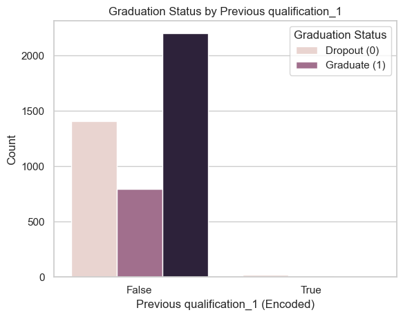

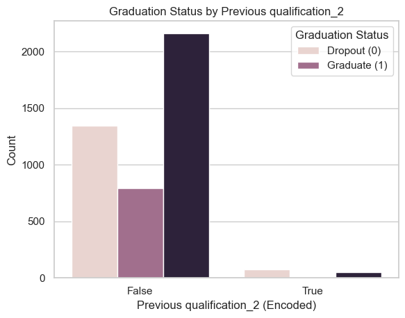

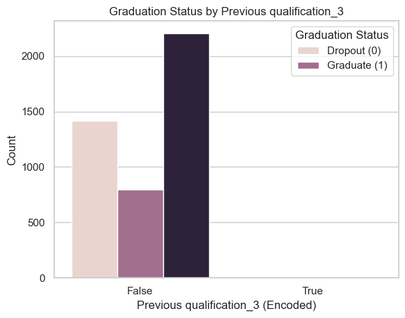

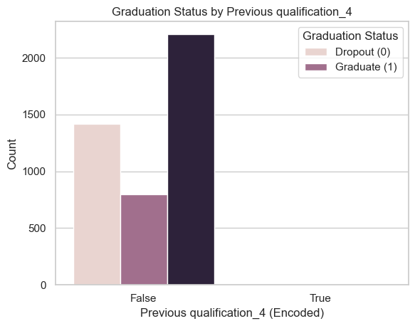

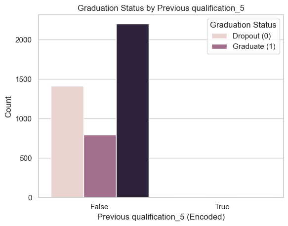

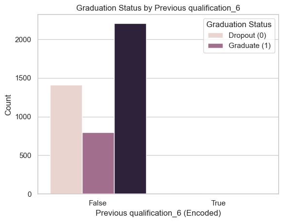

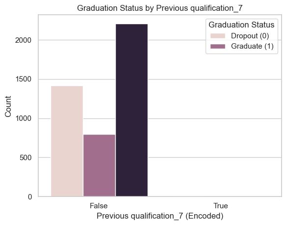

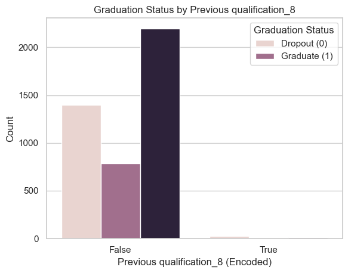

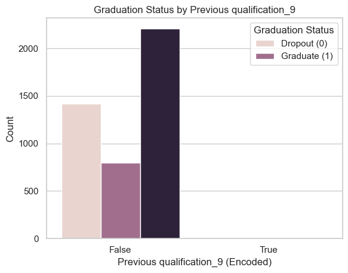

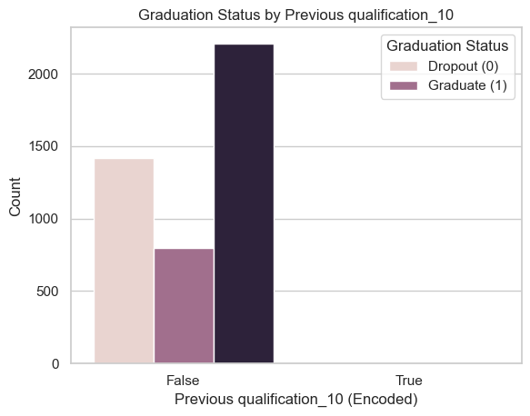

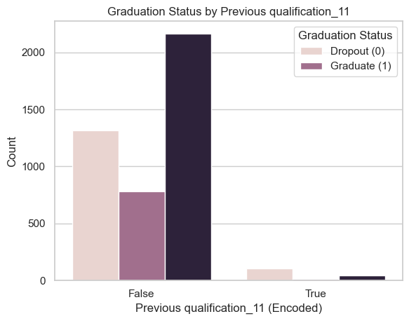

[5 more figures not shown]

```python
# Creating a count plot for each previous qualification category
for col in previous_qual_cols:
    sns.countplot(x=col, hue='Target', data=data)
    plt.title(f'Graduation Status by {col}')
    plt.xlabel(f'{col} (Encoded)')
    plt.ylabel('Count')
    plt.legend(title='Graduation Status', labels=['Dropout (0)', 'Graduate (1)'])
    plt.show()
```

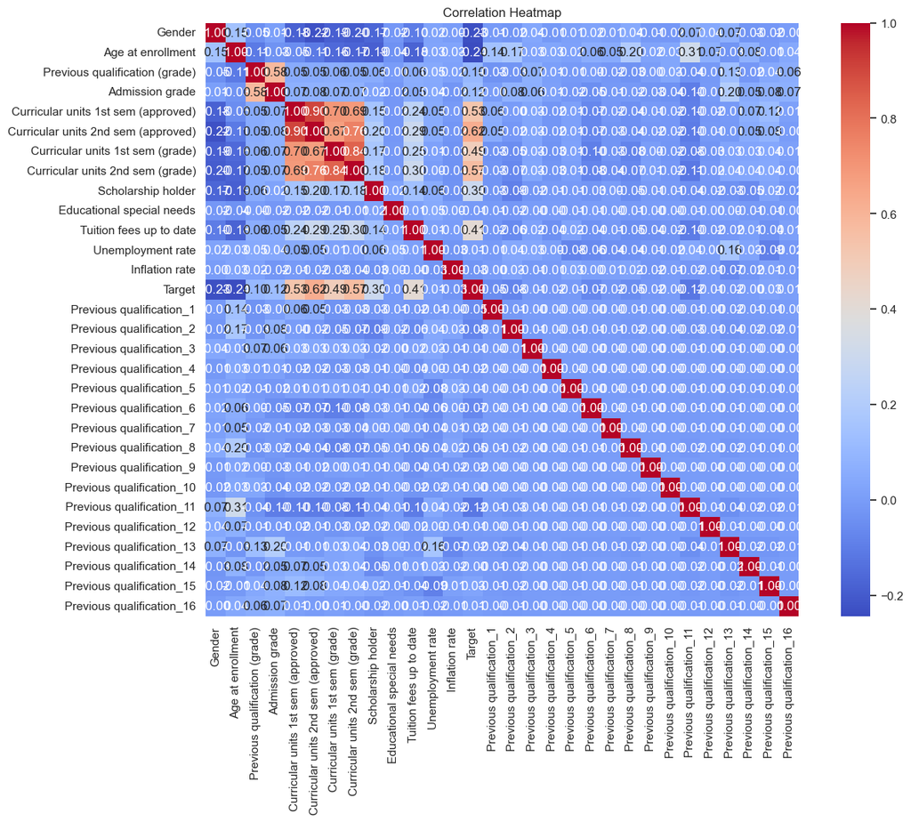

```python
# 4. Correlation Heatmap
plt.figure(figsize=(14, 10))
correlation_matrix = data.corr()
sns.heatmap(correlation_matrix, annot=True, fmt=".2f", cmap='coolwarm', square=True)
plt.title('Correlation Heatmap')
plt.show()
```

# MODELLING AND TRAINING

```python
import joblib# FOR CACHING AND PIPELINING



# Splitting the data into features and target
X = data.drop('Target', axis=1)
y = data['Target']

# Splitting the dataset into training and testing sets
X_train, X_test, y_train, y_test = train_test_split(X, y, test_size=0.2, random_state=42)

# Feature scaling
scaler = StandardScaler()
X_train_scaled = scaler.fit_transform(X_train)
X_test_scaled = scaler.transform(X_test)

# Initializing our models . We are using at least 5 algorithms
models = {
    'Logistic Regression': LogisticRegression(),
    'Decision Tree': DecisionTreeClassifier(),
    'Random Forest': RandomForestClassifier(),
    'Support Vector Machine': SVC(),
    'Gradient Boosting': GradientBoostingClassifier()
}

# Initialize best model tracking
best_model = None
best_accuracy = -1  # Set to -1 so even 0 accuracy will replace it
best_model_name = ""

# Training and evaluating each model
for model_name, model in models.items():
    try:
        model.fit(X_train_scaled, y_train)
        y_pred = model.predict(X_test_scaled)
        accuracy = accuracy_score(y_test, y_pred)

        print(f"{model_name} Accuracy: {accuracy:.2f}")
        print(classification_report(y_test, y_pred))
        print(confusion_matrix(y_test, y_pred))
        print("-" * 60)

        if accuracy > best_accuracy:
            best_accuracy = accuracy
            best_model = model
            best_model_name = model_name

    except Exception as e:
        print(f"Error training {model_name}: {e}")
        print("-" * 60)

# Saving the best model only if and only if it was successfully trained
if best_model is not None:
    joblib.dump(best_model, 'best_model.pkl')
    joblib.dump(scaler, 'scaler.pkl')
    joblib.dump(X.columns.tolist(), 'feature_names.pkl')
    print(f"Best model ({best_model_name}) saved with accuracy: {best_accuracy:.2f}")
else:
    print("No model was successfully trained. Nothing was saved.")
```

```
Logistic Regression Accuracy: 0.74
              precision    recall  f1-score   support

           0       0.82      0.73      0.77       316
           1       0.50      0.23      0.31       151
           2       0.73      0.93      0.81       418

    accuracy                           0.74       885
   macro avg       0.68      0.63      0.63       885
weighted avg       0.72      0.74      0.71       885

[[230  28  58]
 [ 28  34  89]
 [ 24   6 388]]
------------------------------------------------------------
Decision Tree Accuracy: 0.67
              precision    recall  f1-score   support

           0       0.74      0.66      0.70       316
           1       0.36      0.38      0.37       151
           2       0.74      0.78      0.76       418

    accuracy                           0.67       885
   macro avg       0.62      0.61      0.61       885
weighted avg       0.68      0.67      0.67       885

[[210  49  57]
 [ 33  58  60]
 [ 39  52 327]]
------------------------------------------------------------
Random Forest Accuracy: 0.73
              precision    recall  f1-score   support

           0       0.81      0.72      0.77       316
           1       0.42      0.26      0.32       151
           2       0.74      0.91      0.82       418

    accuracy                           0.73       885
   macro avg       0.66      0.63      0.63       885
weighted avg       0.71      0.73      0.71       885
```

[output cut: 21 more lines]

```
              precision    recall  f1-score   support

           0       0.82      0.71      0.76       316
           1       0.42      0.27      0.33       151
           2       0.74      0.91      0.82       418

    accuracy                           0.73       885
   macro avg       0.66      0.63      0.64       885
weighted avg       0.71      0.73      0.72       885

[[225  34  57]
 [ 36  41  74]
 [ 14  23 381]]
------------------------------------------------------------
Best model (Logistic Regression) saved with accuracy: 0.74
```

# VISUALIZING THE PERFORMANCES

```python
import matplotlib.pyplot as plt
import seaborn as sns
from sklearn.metrics import confusion_matrix, classification_report, roc_curve, auc

# Initialize lists to store results
model_names = []
accuracies = []
confusion_matrices = []
class_reports = []

# Train and evaluate each model, storing results for visualization
for model_name, model in models.items():
    # Train the model
    model.fit(X_train, y_train)

    # Make predictions
    y_pred = model.predict(X_test)

    # Store results
    model_names.append(model_name)
    accuracies.append(accuracy_score(y_test, y_pred))
    confusion_matrices.append(confusion_matrix(y_test, y_pred))
    class_reports.append(classification_report(y_test, y_pred, output_dict=True))
```

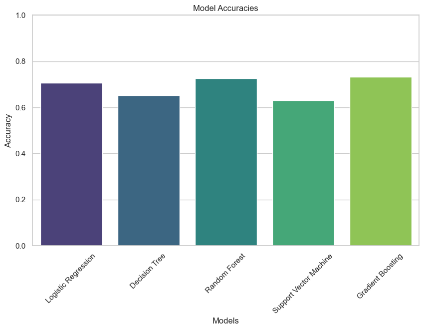

```python
# 1. Bar Chart of Model Accuracies
plt.figure(figsize=(10, 6))
sns.barplot(x=model_names, y=accuracies, palette='viridis')
plt.title('Model Accuracies')
plt.xlabel('Models')
plt.ylabel('Accuracy')
plt.ylim(0, 1)
plt.xticks(rotation=45)
plt.show()
```

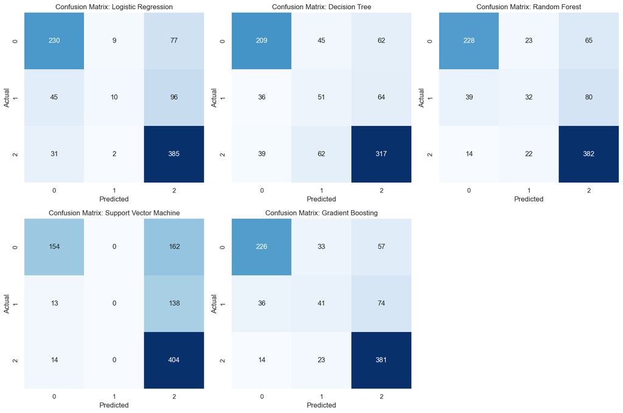

```python
# 2. Confusion Matrices
plt.figure(figsize=(15, 10))
for i, cm in enumerate(confusion_matrices):
    plt.subplot(2, 3, i + 1)
    sns.heatmap(cm, annot=True, fmt='d', cmap='Blues', cbar=False)
    plt.title(f'Confusion Matrix: {model_names[i]}')
    plt.xlabel('Predicted')
    plt.ylabel('Actual')
plt.tight_layout()
plt.show()
```

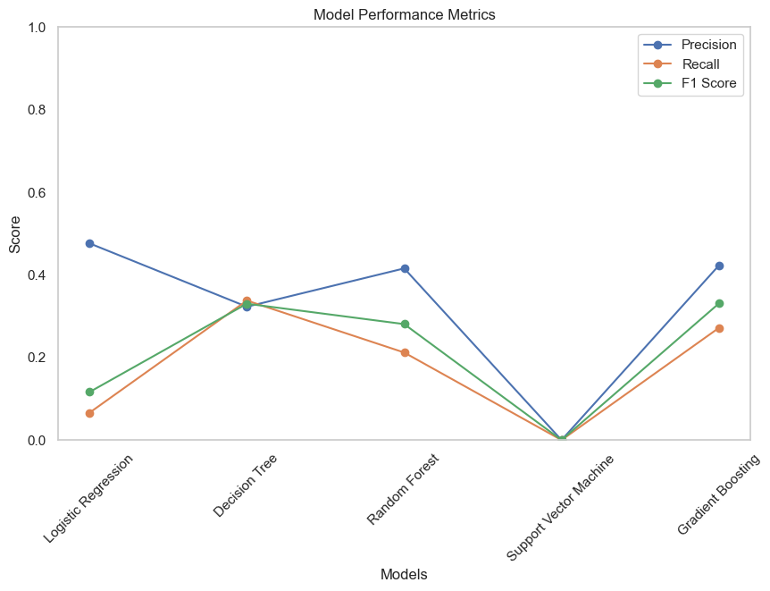

```python
# 3. Classification Report Visualization
# Extract precision, recall, and F1 scores
precision = [report['1']['precision'] for report in class_reports]
recall = [report['1']['recall'] for report in class_reports]
f1_score = [report['1']['f1-score'] for report in class_reports]

x = range(len(model_names))

plt.figure(figsize=(10, 6))
plt.plot(x, precision, marker='o', label='Precision')
plt.plot(x, recall, marker='o', label='Recall')
plt.plot(x, f1_score, marker='o', label='F1 Score')
plt.xticks(x, model_names, rotation=45)
plt.title('Model Performance Metrics')
plt.xlabel('Models')
plt.ylabel('Score')
plt.ylim(0, 1)
plt.legend()
plt.grid()
plt.show()
```

# CREATING A PROGRAM THAT CARRIES OUT THE ACTUAL PREDICTIONS BASED ON NEW DATA INSERTED

```python
import pandas as pd
import joblib

# Loading our model, scaler, and feature names
model = joblib.load('best_model.pkl')
scaler = joblib.load('scaler.pkl')
trained_feature_order = joblib.load('feature_names.pkl')

# Labelling the encodings
label_encodings = {
    'Gender': {'Male': 1, 'Female': 0},
    'Scholarship holder': {'yes': 1, 'no': 0},
    'Educational special needs': {'yes': 1, 'no': 0},
    'Tuition fees up to date': {'yes': 1, 'no': 0},
}

#The function below serves to preprocess the data passed into the program.
def preprocess_input(input_data):
    input_df = pd.DataFrame([input_data])


    for col, mapping in label_encodings.items():
        if col in input_df:
            input_df[col] = input_df[col].map(mapping)


    input_df = pd.get_dummies(input_df, columns=['Previous qualification'], prefix='Previous qualification')

    # Adding any missing columns from training
    for col in trained_feature_order:
        if col not in input_df.columns:
            input_df[col] = 0

    # Reordering to match training
    input_df = input_df[trained_feature_order]

    # Scaling
    scaled = scaler.transform(input_df)
    return scaled

#Function to predict outcome
def predict_outcome(input_data):
    processed = preprocess_input(input_data)
    prediction = model.predict(processed)
    return "Graduate" if prediction[0] == 1 else "Dropout"

#Function to input data
def main():
    input_data = {
        'Gender': "Male",
        'Age at enrollment': 34,
        'Previous qualification': 1,
        'Previous qualification (grade)': 14,
        'Admission grade': 140,
        'Curricular units 1st sem (approved)': 6,
        'Curricular units 2nd sem (approved)': 5,
        'Curricular units 1st sem (grade)': 13,
        'Curricular units 2nd sem (grade)': 12,
        'Scholarship holder': "no",
        'Educational special needs': "no",
        'Tuition fees up to date': "yes",
        'Unemployment rate': 5.0,
        'Inflation rate': 2.5,
    }

    outcome = predict_outcome(input_data)
    print(f"The predicted outcome is: {outcome}")

if __name__ == "__main__":
    main()
```

```
The predicted outcome is: Dropout
```

# 📄 Summary Report: Model Evaluation Findings

### 🎓 Project Title: **Dropout or Graduate Classifier**

## 🎯 Objective

Using historical data, the project evaluates different classification algorithms to determine the best-performing model.

## 🤖 Models Evaluated

The following supervised learning models were trained and tested:

- **Logistic Regression**
- **Decision Tree Classifier**
- **Random Forest Classifier**
- **Support Vector Machine (SVM)**
- **Gradient Boosting Classifier**

## 📊 Evaluation Metrics

Each model was evaluated based on:

- **Accuracy** – Overall correctness of predictions
- **Precision, Recall, F1-Score** – Class-wise and weighted performance
- **Confusion Matrix** – Distribution of predictions across classes

## 🧪 Results Summary

[output not shown]